# WUM - Praca domowa 4

Patryk Wrona

14 kwietnia 2020

# 1 Ładowanie zbiorów danych

W tej pracy domowej wykorzystam 2 zbiory danych w celu modelowania SVM z losowym strojeniem hiperparametrów:

- *apartments* (z pakietu DALEX)
- *diabetes* (z pakietu VIM)

```r
data(apartments, package = "DALEX")
data(diabetes, package = "VIM")
```

# 2 Apartments

```r
# PRAWIE ROWNOLICZNE KLASY:
apartments %>% group_by(district) %>% count() %>% arrange(desc(n))
```

| district | n |
| --- | --- |
| Mokotow | 107 |
| Wola | 106 |
| Ursus | 105 |
| Ursynow | 103 |
| Srodmiescie | 100 |
| Bemowo | 98 |
| Zoliborz | 97 |
| Bielany | 96 |
| Ochota | 96 |
| Praga | 92 |

Dzielnice (zmienna celu) w zbiorze danych są w przybliżeniu równoliczne - nasz zbiór danych jest zbalansowany.

## 2.1 Rzut okiem na zbiór

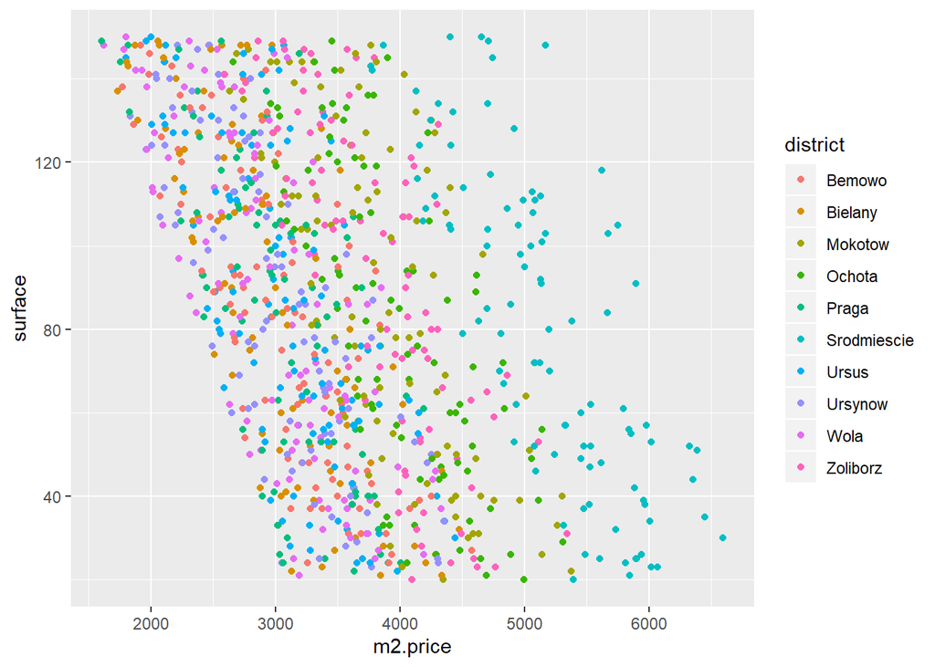

```r
ggplot( data = apartments,
        aes(x = m2.price, y = surface, color =  district)) +
      geom_point()
```

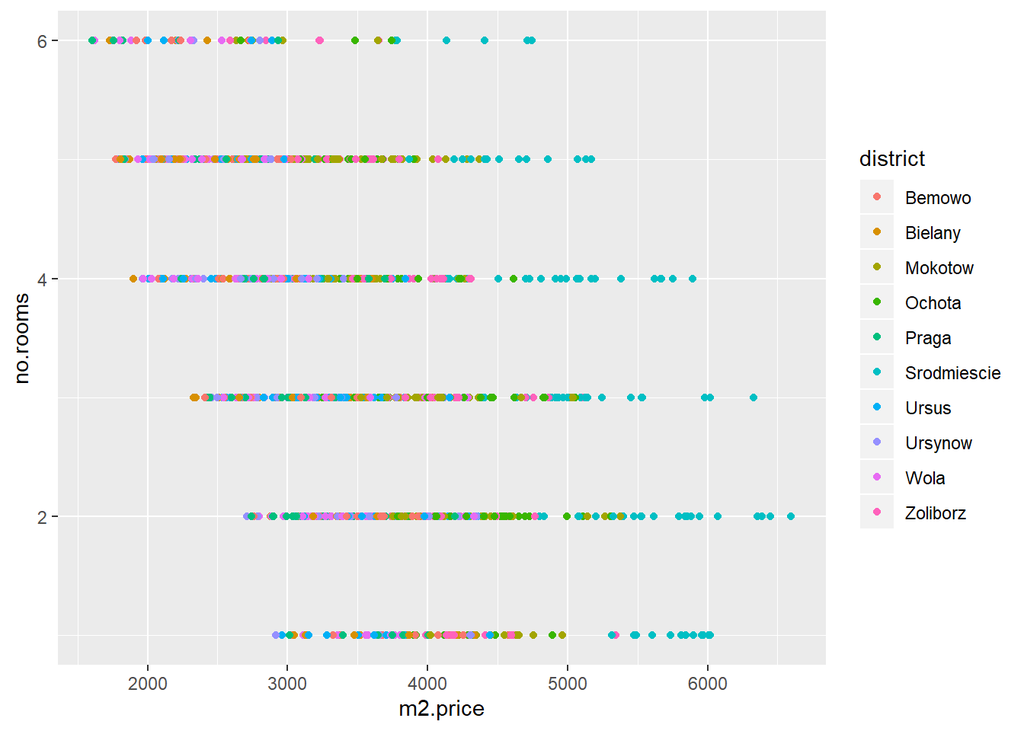

```r
ggplot( data = apartments,
        aes(x = m2.price, y = no.rooms, color =  district)) +
      geom_point()
```

Śródmieście jest jako jedyne liniowo separowalne. Należy się spodziewać, że modele będą dobrze dokonywały predykcji tylko Śródmieścia, a reszta dzielnic będzie bardziej “chybił trafił”. Spodziewam się (hipoteza), że jądro Gaussowskie będzie w tym przypadku najlepsze, gdyż nauczy się klasyfikować dzielnice (inne niż Śródmieście) lepiej od innych jąder: liniowego i wielomianowego.

## 2.2 Train/test 80%/20% split

```r
indexes <- createDataPartition(apartments$district, p = 0.8, list = F )

trainset <- apartments[indexes,]
testset <- apartments[-indexes,]
```

## 2.3 Modele - bez skalowania

Najpierw rozważmy **modele o hiperparametrach domyślnych**, które potem porównamy z modelami strojonymi:

```r
set.seed(44)
# Fit svmRadial:
model <- train(
  district ~ . ,
  data = trainset,
  method = "svmRadial"
)
pred <- predict(model, newdata = testset)
confusionMatrix(pred , testset$district)
```

```
## Confusion Matrix and Statistics
##
##              Reference
## Prediction    Bemowo Bielany Mokotow Ochota Praga Srodmiescie Ursus
##   Bemowo           4       4       0      0     3           0     5
##   Bielany          5       1       0      0     3           0     5
##   Mokotow          0       1      10      6     0           0     0
##   Ochota           0       0       3      5     0           0     0
##   Praga            2       0       0      0     1           0     2
##   Srodmiescie      0       0       0      0     0          20     0
##   Ursus            3       5       0      0     4           0     4
##   Ursynow          3       4       0      0     3           0     1
##   Wola             2       4       0      0     4           0     4
##   Zoliborz         0       0       8      8     0           0     0
##              Reference
## Prediction    Ursynow Wola Zoliborz
##   Bemowo            3    0        0
##   Bielany           2    5        0
##   Mokotow           0    0        7
##   Ochota            0    0        2
##   Praga             4    4        0
##   Srodmiescie       0    0        0
##   Ursus             5    4        0
##   Ursynow           2    5        0
##   Wola              4    3        0
##   Zoliborz          0    0       10
##
## Overall Statistics
##
##                Accuracy : 0.3046
##                  95% CI : (0.2412, 0.374)
##     No Information Rate : 0.1066
##     P-Value [Acc > NIR] : 2.97e-14
##
##                   Kappa : 0.2267
##
##  Mcnemar's Test P-Value : NA
##
## Statistics by Class:
##
```

[output cut: 21 more lines]

```
## Pos Pred Value             0.1600        0.11111     0.14286
## Neg Pred Value             0.9012        0.89944     0.89773
## Prevalence                 0.1066        0.10152     0.10660
## Detection Rate             0.0203        0.01015     0.01523
## Detection Prevalence       0.1269        0.09137     0.10660
## Balanced Accuracy          0.5356        0.50480     0.52029
##                      Class: Zoliborz
## Sensitivity                  0.52632
## Specificity                  0.91011
## Pos Pred Value               0.38462
## Neg Pred Value               0.94737
## Prevalence                   0.09645
## Detection Rate               0.05076
## Detection Prevalence         0.13198
## Balanced Accuracy            0.71821
```

```r
set.seed(44)
# Fit svmPoly:
model <- train(
  district ~ . ,
  data = trainset,
  method = "svmPoly"
)
pred <- predict(model, newdata = testset)
confusionMatrix(pred , testset$district)
```

```
## Confusion Matrix and Statistics
##
##              Reference
## Prediction    Bemowo Bielany Mokotow Ochota Praga Srodmiescie Ursus
##   Bemowo           6       4       0      0     6           0     4
##   Bielany          2       1       0      0     2           0     3
##   Mokotow          0       0       8      3     0           0     0
##   Ochota           0       0       3      6     0           0     0
##   Praga            2       2       0      0     1           0     3
##   Srodmiescie      0       0       0      0     0          20     0
##   Ursus            4       6       0      0     4           0     4
##   Ursynow          3       4       0      0     3           0     4
##   Wola             2       2       0      0     2           0     3
##   Zoliborz         0       0      10     10     0           0     0
##              Reference
## Prediction    Ursynow Wola Zoliborz
##   Bemowo            8    1        0
##   Bielany           1    3        0
##   Mokotow           0    0        8
##   Ochota            0    0        2
##   Praga             4    5        0
##   Srodmiescie       0    0        0
##   Ursus             4    4        0
##   Ursynow           0    6        0
##   Wola              3    2        0
##   Zoliborz          0    0        9
##
## Overall Statistics
##
##                Accuracy : 0.2893
##                  95% CI : (0.2271, 0.3581)
##     No Information Rate : 0.1066
##     P-Value [Acc > NIR] : 1.373e-12
##
##                   Kappa : 0.2103
##
##  Mcnemar's Test P-Value : NA
##
## Statistics by Class:
##
```

[output cut: 21 more lines]

```
## Pos Pred Value             0.1538         0.0000     0.14286
## Neg Pred Value             0.9006         0.8870     0.89617
## Prevalence                 0.1066         0.1015     0.10660
## Detection Rate             0.0203         0.0000     0.01015
## Detection Prevalence       0.1320         0.1015     0.07107
## Balanced Accuracy          0.5327         0.4435     0.51353
##                      Class: Zoliborz
## Sensitivity                  0.47368
## Specificity                  0.88764
## Pos Pred Value               0.31034
## Neg Pred Value               0.94048
## Prevalence                   0.09645
## Detection Rate               0.04569
## Detection Prevalence         0.14721
## Balanced Accuracy            0.68066
```

```r
set.seed(44)
# Fit svmLinear:
model <- train(
  district ~ . ,
  data = trainset,
  method = "svmLinear"
)
pred <- predict(model, newdata = testset)
confusionMatrix(pred , testset$district)
```

```
## Confusion Matrix and Statistics
##
##              Reference
## Prediction    Bemowo Bielany Mokotow Ochota Praga Srodmiescie Ursus
##   Bemowo           8       6       0      0     4           0     3
##   Bielany          1       0       0      0     2           0     1
##   Mokotow          0       0       7      4     0           0     0
##   Ochota           0       0       6      7     0           0     0
##   Praga            3       2       0      0     3           0     2
##   Srodmiescie      0       0       0      0     0          20     0
##   Ursus            3       4       0      0     3           0     4
##   Ursynow          2       3       0      0     2           0     4
##   Wola             2       4       0      0     4           0     7
##   Zoliborz         0       0       8      8     0           0     0
##              Reference
## Prediction    Ursynow Wola Zoliborz
##   Bemowo            4    2        0
##   Bielany           3    0        0
##   Mokotow           0    0        5
##   Ochota            0    0        5
##   Praga             5    4        0
##   Srodmiescie       0    0        0
##   Ursus             4    4        0
##   Ursynow           3    6        0
##   Wola              1    5        0
##   Zoliborz          0    0        9
##
## Overall Statistics
##
##                Accuracy : 0.335
##                  95% CI : (0.2695, 0.4056)
##     No Information Rate : 0.1066
##     P-Value [Acc > NIR] : < 2.2e-16
##
##                   Kappa : 0.261
##
##  Mcnemar's Test P-Value : NA
##
## Statistics by Class:
##
```

[output cut: 21 more lines]

```
## Pos Pred Value             0.1818        0.15000     0.21739
## Neg Pred Value             0.9029        0.90395     0.90805
## Prevalence                 0.1066        0.10152     0.10660
## Detection Rate             0.0203        0.01523     0.02538
## Detection Prevalence       0.1117        0.10152     0.11675
## Balanced Accuracy          0.5441        0.52698     0.56791
##                      Class: Zoliborz
## Sensitivity                  0.47368
## Specificity                  0.91011
## Pos Pred Value               0.36000
## Neg Pred Value               0.94186
## Prevalence                   0.09645
## Detection Rate               0.04569
## Detection Prevalence         0.12690
## Balanced Accuracy            0.69190
```

Modele ze strojonymi hiperparametrami po losowej siatce:

```r
set.seed(44)
# Fit svmRadial:
model <- train(
  district ~ . ,
  tuneLength = 20, # ilość losowań
  data = trainset,
  method = "svmRadial",
  trControl = trainControl(
    method = "cv",
    number = 5,
    verboseIter = F,
    search = "random"# losowe strojenie hiperparametrow
  )
)
pred <- predict(model, newdata = testset)
confusionMatrix(pred , testset$district)
```

```
## Confusion Matrix and Statistics
##
##              Reference
## Prediction    Bemowo Bielany Mokotow Ochota Praga Srodmiescie Ursus
##   Bemowo           7       5       0      0     3           0     6
##   Bielany          1       2       0      0     4           0     3
##   Mokotow          0       0       9      6     0           0     0
##   Ochota           0       0       6      6     0           0     0
##   Praga            4       3       0      0     1           0     3
##   Srodmiescie      0       0       0      0     0          20     0
##   Ursus            4       4       0      0     4           0     4
##   Ursynow          1       3       0      0     2           0     2
##   Wola             2       2       0      0     4           0     3
##   Zoliborz         0       0       6      7     0           0     0
##              Reference
## Prediction    Ursynow Wola Zoliborz
##   Bemowo            7    2        0
##   Bielany           1    3        0
##   Mokotow           0    0        5
##   Ochota            0    0        4
##   Praga             6    7        0
##   Srodmiescie       0    0        0
##   Ursus             3    3        0
##   Ursynow           0    4        0
##   Wola              3    2        0
##   Zoliborz          0    0       10
##
## Overall Statistics
##
##                Accuracy : 0.3096
##                  95% CI : (0.2459, 0.3793)
##     No Information Rate : 0.1066
##     P-Value [Acc > NIR] : 7.894e-15
##
##                   Kappa : 0.2332
##
##  Mcnemar's Test P-Value : NA
##
## Statistics by Class:
##
```

[output cut: 21 more lines]

```
## Pos Pred Value             0.1818        0.00000     0.12500
## Neg Pred Value             0.9029        0.89189     0.89503
## Prevalence                 0.1066        0.10152     0.10660
## Detection Rate             0.0203        0.00000     0.01015
## Detection Prevalence       0.1117        0.06091     0.08122
## Balanced Accuracy          0.5441        0.46610     0.50785
##                      Class: Zoliborz
## Sensitivity                  0.52632
## Specificity                  0.92697
## Pos Pred Value               0.43478
## Neg Pred Value               0.94828
## Prevalence                   0.09645
## Detection Rate               0.05076
## Detection Prevalence         0.11675
## Balanced Accuracy            0.72664
```

```r
set.seed(44)
# Fit svmPoly:
model <- train(
  district ~ . ,
  tuneLength = 20, # ilość losowań
  data = trainset,
  method = "svmPoly",
  trControl = trainControl(
    method = "cv",
    number = 5,
    verboseIter = F,
    search = "random" # losowe strojenie hiperparametrow
  )
)
pred <- predict(model, newdata = testset)
confusionMatrix(pred , testset$district)
```

```
## Confusion Matrix and Statistics
##
##              Reference
## Prediction    Bemowo Bielany Mokotow Ochota Praga Srodmiescie Ursus
##   Bemowo           4       4       0      0     8           0     5
##   Bielany          3       4       1      0     1           0     3
##   Mokotow          0       0       7      5     0           0     0
##   Ochota           0       0       8      6     0           0     0
##   Praga            4       2       0      0     2           0     4
##   Srodmiescie      0       0       0      0     0          20     0
##   Ursus            3       4       0      0     2           0     4
##   Ursynow          2       3       0      0     3           0     2
##   Wola             3       2       0      0     2           0     3
##   Zoliborz         0       0       5      8     0           0     0
##              Reference
## Prediction    Ursynow Wola Zoliborz
##   Bemowo            7    1        0
##   Bielany           1    6        0
##   Mokotow           0    0        6
##   Ochota            0    0        4
##   Praga             7    8        0
##   Srodmiescie       0    0        0
##   Ursus             3    1        0
##   Ursynow           0    3        0
##   Wola              2    2        0
##   Zoliborz          0    0        9
##
## Overall Statistics
##
##                Accuracy : 0.2944
##                  95% CI : (0.2318, 0.3634)
##     No Information Rate : 0.1066
##     P-Value [Acc > NIR] : 3.919e-13
##
##                   Kappa : 0.2168
##
##  Mcnemar's Test P-Value : NA
##
## Statistics by Class:
##
```

[output cut: 21 more lines]

```
## Pos Pred Value            0.23529        0.00000     0.14286
## Neg Pred Value            0.90556        0.89130     0.89617
## Prevalence                0.10660        0.10152     0.10660
## Detection Rate            0.02030        0.00000     0.01015
## Detection Prevalence      0.08629        0.06599     0.07107
## Balanced Accuracy         0.55831        0.46328     0.51353
##                      Class: Zoliborz
## Sensitivity                  0.47368
## Specificity                  0.92697
## Pos Pred Value               0.40909
## Neg Pred Value               0.94286
## Prevalence                   0.09645
## Detection Rate               0.04569
## Detection Prevalence         0.11168
## Balanced Accuracy            0.70033
```

```r
set.seed(44)
# Fit svmLinear:
model <- train(
  district ~ . ,
  tuneLength = 20, # ilość losowań
  data = trainset,
  method = "svmLinear",
  trControl = trainControl(
    method = "cv",
    number = 5,
    verboseIter = F,
    search = "random"# losowe strojenie hiperparametrow
  )
)
pred <- predict(model, newdata = testset)
confusionMatrix(pred , testset$district)
```

```
## Confusion Matrix and Statistics
##
##              Reference
## Prediction    Bemowo Bielany Mokotow Ochota Praga Srodmiescie Ursus
##   Bemowo           9       7       0      0     4           0     4
##   Bielany          1       0       0      0     4           0     1
##   Mokotow          0       0       7      4     0           0     0
##   Ochota           0       0       6      7     0           0     0
##   Praga            2       0       0      0     2           0     1
##   Srodmiescie      0       0       0      0     0          20     0
##   Ursus            3       3       0      0     3           0     4
##   Ursynow          2       3       0      0     2           0     4
##   Wola             2       6       0      0     3           0     7
##   Zoliborz         0       0       8      8     0           0     0
##              Reference
## Prediction    Ursynow Wola Zoliborz
##   Bemowo            5    4        0
##   Bielany           3    0        0
##   Mokotow           0    0        5
##   Ochota            0    0        5
##   Praga             2    2        0
##   Srodmiescie       0    0        0
##   Ursus             4    4        0
##   Ursynow           4    6        0
##   Wola              2    5        0
##   Zoliborz          0    0        9
##
## Overall Statistics
##
##                Accuracy : 0.3401
##                  95% CI : (0.2743, 0.4108)
##     No Information Rate : 0.1066
##     P-Value [Acc > NIR] : < 2.2e-16
##
##                   Kappa : 0.2664
##
##  Mcnemar's Test P-Value : NA
##
## Statistics by Class:
##
```

[output cut: 21 more lines]

```
## Pos Pred Value             0.1905         0.1905     0.20000
## Neg Pred Value             0.9034         0.9091     0.90698
## Prevalence                 0.1066         0.1015     0.10660
## Detection Rate             0.0203         0.0203     0.02538
## Detection Prevalence       0.1066         0.1066     0.12690
## Balanced Accuracy          0.5469         0.5520     0.56223
##                      Class: Zoliborz
## Sensitivity                  0.47368
## Specificity                  0.91011
## Pos Pred Value               0.36000
## Neg Pred Value               0.94186
## Prevalence                   0.09645
## Detection Rate               0.04569
## Detection Prevalence         0.12690
## Balanced Accuracy            0.69190
```

O dziwo liniowe jądro poradziło sobie lepiej od Gaussowskiego, a oto jego hiperparametry:

```r
model
```

```
## Support Vector Machines with Linear Kernel
##
## 803 samples
##   5 predictor
##  10 classes: 'Bemowo', 'Bielany', 'Mokotow', 'Ochota', 'Praga', 'Srodmiescie', 'Ursus', 'Ursynow', 'Wola', 'Zoliborz'
##
## No pre-processing
## Resampling: Cross-Validated (5 fold)
## Summary of sample sizes: 641, 642, 644, 641, 644
## Resampling results across tuning parameters:
##
##   C             Accuracy   Kappa
##     0.03129402  0.2851269  0.2027541
##     0.04367308  0.2964473  0.2158689
##     0.05511047  0.2914704  0.2105890
##     0.05645660  0.2951972  0.2147374
##     0.08116638  0.2603037  0.1759427
##     0.10362829  0.2577803  0.1735069
##     0.13883318  0.2653042  0.1821314
##     0.14554670  0.2690622  0.1863776
##     0.20543582  0.2665854  0.1837845
##     0.25472338  0.2703433  0.1879992
##     0.69234659  0.3027523  0.2244275
##     1.92828131  0.2926817  0.2134112
##     2.83861648  0.2889081  0.2093843
##     2.88616547  0.2889081  0.2094120
##     3.26674605  0.2876736  0.2082218
##     3.33622552  0.2876736  0.2082216
##     6.12200604  0.2876969  0.2083831
##    12.55283489  0.2864546  0.2069948
##    24.58197640  0.2852201  0.2055834
##   158.07201312  0.2839622  0.2042012
##
## Accuracy was used to select the optimal model using the largest value.
## The final value used for the model was C = 0.6923466.
```

## 2.4 Ze skalowaniem

Teraz zbadam czy skalowanie zmiennych ma duży wpływ w przypadku *apartments*. Wyznaczę **Accuracy** modeli ze skalowaniem. Poniżej wykonuję skalowanie zmiennych ilościowych, czyli wszystkich oprócz zmiennej celu:

```r
trainset[,1:5] <- trainset[,1:5] %>% scale(center = F, scale = T)
testset[,1:5] <- testset[,1:5] %>% scale(center = F, scale = T)
```

Najpierw rozważmy **modele o hiperparametrach domyślnych**, które potem porównamy z modelami strojonymi:

```r
set.seed(44)
# Fit svmRadial:
model <- train(
  district ~ . ,
  data = trainset,
  method = "svmRadial"
)
pred <- predict(model, newdata = testset)
confusionMatrix(pred , testset$district)
```

```
## Confusion Matrix and Statistics
##
##              Reference
## Prediction    Bemowo Bielany Mokotow Ochota Praga Srodmiescie Ursus
##   Bemowo           4       4       0      0     4           0     6
##   Bielany          3       1       1      0     3           0     6
##   Mokotow          0       1       8      4     0           0     0
##   Ochota           0       0       4      5     0           0     1
##   Praga            2       0       0      0     2           0     1
##   Srodmiescie      0       0       0      0     0          20     0
##   Ursus            4       5       0      0     4           0     3
##   Ursynow          4       4       0      0     2           0     2
##   Wola             2       4       0      0     3           0     2
##   Zoliborz         0       0       8     10     0           0     0
##              Reference
## Prediction    Ursynow Wola Zoliborz
##   Bemowo            3    2        0
##   Bielany           2    4        0
##   Mokotow           0    0        7
##   Ochota            0    0        2
##   Praga             4    4        0
##   Srodmiescie       0    0        0
##   Ursus             5    4        0
##   Ursynow           2    4        0
##   Wola              4    3        0
##   Zoliborz          0    0       10
##
## Overall Statistics
##
##                Accuracy : 0.2944
##                  95% CI : (0.2318, 0.3634)
##     No Information Rate : 0.1066
##     P-Value [Acc > NIR] : 3.919e-13
##
##                   Kappa : 0.2157
##
##  Mcnemar's Test P-Value : NA
##
## Statistics by Class:
##
```

[output cut: 21 more lines]

```
## Pos Pred Value            0.12000        0.11111     0.16667
## Neg Pred Value            0.89535        0.89944     0.89944
## Prevalence                0.10660        0.10152     0.10660
## Detection Rate            0.01523        0.01015     0.01523
## Detection Prevalence      0.12690        0.09137     0.09137
## Balanced Accuracy         0.50893        0.50480     0.52881
##                      Class: Zoliborz
## Sensitivity                  0.52632
## Specificity                  0.89888
## Pos Pred Value               0.35714
## Neg Pred Value               0.94675
## Prevalence                   0.09645
## Detection Rate               0.05076
## Detection Prevalence         0.14213
## Balanced Accuracy            0.71260
```

```r
set.seed(44)
# Fit svmPoly:
model <- train(
  district ~ . ,
  data = trainset,
  method = "svmPoly"
)
pred <- predict(model, newdata = testset)
confusionMatrix(pred , testset$district)
```

```
## Confusion Matrix and Statistics
##
##              Reference
## Prediction    Bemowo Bielany Mokotow Ochota Praga Srodmiescie Ursus
##   Bemowo           6       5       0      0     8           0     5
##   Bielany          2       1       0      0     1           0     3
##   Mokotow          0       0       5      2     0           0     0
##   Ochota           0       0       5      6     0           0     0
##   Praga            2       2       0      0     2           0     3
##   Srodmiescie      0       0       0      0     0          20     0
##   Ursus            4       5       0      0     3           0     4
##   Ursynow          3       3       0      0     3           0     4
##   Wola             2       3       0      0     1           0     2
##   Zoliborz         0       0      11     11     0           0     0
##              Reference
## Prediction    Ursynow Wola Zoliborz
##   Bemowo            9    1        0
##   Bielany           1    3        0
##   Mokotow           0    0        5
##   Ochota            0    0        2
##   Praga             4    6        0
##   Srodmiescie       0    0        0
##   Ursus             4    3        0
##   Ursynow           0    7        0
##   Wola              2    1        0
##   Zoliborz          0    0       12
##
## Overall Statistics
##
##                Accuracy : 0.2893
##                  95% CI : (0.2271, 0.3581)
##     No Information Rate : 0.1066
##     P-Value [Acc > NIR] : 1.373e-12
##
##                   Kappa : 0.2109
##
##  Mcnemar's Test P-Value : NA
##
## Statistics by Class:
##
```

[output cut: 21 more lines]

```
## Pos Pred Value             0.1739         0.0000    0.090909
## Neg Pred Value             0.9023         0.8870    0.892473
## Prevalence                 0.1066         0.1015    0.106599
## Detection Rate             0.0203         0.0000    0.005076
## Detection Prevalence       0.1168         0.1015    0.055838
## Balanced Accuracy          0.5413         0.4435    0.495400
##                      Class: Zoliborz
## Sensitivity                  0.63158
## Specificity                  0.87640
## Pos Pred Value               0.35294
## Neg Pred Value               0.95706
## Prevalence                   0.09645
## Detection Rate               0.06091
## Detection Prevalence         0.17259
## Balanced Accuracy            0.75399
```

```r
set.seed(44)
# Fit svmLinear:
model <- train(
  district ~ . ,
  data = trainset,
  method = "svmLinear"
)
pred <- predict(model, newdata = testset)
confusionMatrix(pred , testset$district)
```

```
## Confusion Matrix and Statistics
##
##              Reference
## Prediction    Bemowo Bielany Mokotow Ochota Praga Srodmiescie Ursus
##   Bemowo           9       6       0      0     5           0     3
##   Bielany          1       1       0      0     3           0     2
##   Mokotow          0       0       6      4     0           0     0
##   Ochota           0       0       6      7     0           0     0
##   Praga            3       2       0      0     3           0     2
##   Srodmiescie      0       0       0      0     0          20     0
##   Ursus            3       3       0      0     3           0     4
##   Ursynow          2       3       0      0     1           0     4
##   Wola             1       4       0      0     3           0     6
##   Zoliborz         0       0       9      8     0           0     0
##              Reference
## Prediction    Ursynow Wola Zoliborz
##   Bemowo            5    3        0
##   Bielany           3    1        0
##   Mokotow           0    0        5
##   Ochota            0    0        5
##   Praga             4    4        0
##   Srodmiescie       0    0        0
##   Ursus             4    3        0
##   Ursynow           3    7        0
##   Wola              1    3        0
##   Zoliborz          0    0        9
##
## Overall Statistics
##
##                Accuracy : 0.3299
##                  95% CI : (0.2648, 0.4003)
##     No Information Rate : 0.1066
##     P-Value [Acc > NIR] : < 2.2e-16
##
##                   Kappa : 0.2557
##
##  Mcnemar's Test P-Value : NA
##
## Statistics by Class:
##
```

[output cut: 21 more lines]

```
## Pos Pred Value             0.2000        0.15000     0.16667
## Neg Pred Value             0.9040        0.90395     0.89944
## Prevalence                 0.1066        0.10152     0.10660
## Detection Rate             0.0203        0.01523     0.01523
## Detection Prevalence       0.1015        0.10152     0.09137
## Balanced Accuracy          0.5498        0.52698     0.52881
##                      Class: Zoliborz
## Sensitivity                  0.47368
## Specificity                  0.90449
## Pos Pred Value               0.34615
## Neg Pred Value               0.94152
## Prevalence                   0.09645
## Detection Rate               0.04569
## Detection Prevalence         0.13198
## Balanced Accuracy            0.68909
```

Modele ze strojonymi hiperparametrami po losowej siatce:

```r
set.seed(44)
# Fit svmRadial:
model <- train(
  district ~ . ,
  tuneLength = 20, # ilość losowań
  data = trainset,
  method = "svmRadial",
  trControl = trainControl(
    method = "cv",
    number = 5,
    verboseIter = F,
    search = "random"# losowe strojenie hiperparametrow
  )
)
pred <- predict(model, newdata = testset)
confusionMatrix(pred , testset$district)
```

```
## Confusion Matrix and Statistics
##
##              Reference
## Prediction    Bemowo Bielany Mokotow Ochota Praga Srodmiescie Ursus
##   Bemowo           7       6       0      0     5           0     5
##   Bielany          2       2       1      0     2           0     4
##   Mokotow          0       0       9      6     0           0     0
##   Ochota           0       0       5      6     0           0     0
##   Praga            4       3       0      0     2           0     3
##   Srodmiescie      0       0       0      0     0          20     0
##   Ursus            4       3       0      0     4           0     5
##   Ursynow          0       2       0      0     2           0     2
##   Wola             2       3       0      0     3           0     2
##   Zoliborz         0       0       6      7     0           0     0
##              Reference
## Prediction    Ursynow Wola Zoliborz
##   Bemowo            5    3        0
##   Bielany           2    3        0
##   Mokotow           0    0        4
##   Ochota            0    0        3
##   Praga             6    6        0
##   Srodmiescie       0    0        0
##   Ursus             2    4        0
##   Ursynow           2    3        0
##   Wola              3    2        0
##   Zoliborz          0    0       12
##
## Overall Statistics
##
##                Accuracy : 0.3401
##                  95% CI : (0.2743, 0.4108)
##     No Information Rate : 0.1066
##     P-Value [Acc > NIR] : < 2.2e-16
##
##                   Kappa : 0.2672
##
##  Mcnemar's Test P-Value : NA
##
## Statistics by Class:
##
```

[output cut: 21 more lines]

```
## Pos Pred Value            0.22727        0.18182     0.13333
## Neg Pred Value            0.90857        0.90323     0.89560
## Prevalence                0.10660        0.10152     0.10660
## Detection Rate            0.02538        0.01015     0.01015
## Detection Prevalence      0.11168        0.05584     0.07614
## Balanced Accuracy         0.57075        0.52458     0.51069
##                      Class: Zoliborz
## Sensitivity                  0.63158
## Specificity                  0.92697
## Pos Pred Value               0.48000
## Neg Pred Value               0.95930
## Prevalence                   0.09645
## Detection Rate               0.06091
## Detection Prevalence         0.12690
## Balanced Accuracy            0.77927
```

```r
set.seed(44)
# Fit svmPoly:
model <- train(
  district ~ . ,
  tuneLength = 20, # ilość losowań
  data = trainset,
  method = "svmPoly",
  trControl = trainControl(
    method = "cv",
    number = 5,
    verboseIter = F,
    search = "random"# losowe strojenie hiperparametrow
  )
)
pred <- predict(model, newdata = testset)
confusionMatrix(pred , testset$district)
```

```
## Confusion Matrix and Statistics
##
##              Reference
## Prediction    Bemowo Bielany Mokotow Ochota Praga Srodmiescie Ursus
##   Bemowo           6       6       0      0     9           0     5
##   Bielany          2       3       1      0     1           0     2
##   Mokotow          0       0       7      6     0           0     0
##   Ochota           0       0       8      6     0           0     0
##   Praga            4       2       0      0     3           0     4
##   Srodmiescie      0       0       0      0     0          20     0
##   Ursus            3       4       0      0     2           0     6
##   Ursynow          1       2       0      0     2           0     2
##   Wola             3       2       0      0     1           0     2
##   Zoliborz         0       0       5      7     0           0     0
##              Reference
## Prediction    Ursynow Wola Zoliborz
##   Bemowo            7    2        0
##   Bielany           1    4        0
##   Mokotow           0    0        5
##   Ochota            0    0        4
##   Praga             7    9        0
##   Srodmiescie       0    0        0
##   Ursus             3    1        0
##   Ursynow           0    4        0
##   Wola              2    1        0
##   Zoliborz          0    0       10
##
## Overall Statistics
##
##                Accuracy : 0.3147
##                  95% CI : (0.2506, 0.3845)
##     No Information Rate : 0.1066
##     P-Value [Acc > NIR] : 2.05e-15
##
##                   Kappa : 0.2394
##
##  Mcnemar's Test P-Value : NA
##
## Statistics by Class:
##
```

[output cut: 21 more lines]

```
## Pos Pred Value            0.31579        0.00000    0.090909
## Neg Pred Value            0.91573        0.89247    0.892473
## Prevalence                0.10660        0.10152    0.106599
## Detection Rate            0.03046        0.00000    0.005076
## Detection Prevalence      0.09645        0.05584    0.055838
## Balanced Accuracy         0.60593        0.46893    0.495400
##                      Class: Zoliborz
## Sensitivity                  0.52632
## Specificity                  0.93258
## Pos Pred Value               0.45455
## Neg Pred Value               0.94857
## Prevalence                   0.09645
## Detection Rate               0.05076
## Detection Prevalence         0.11168
## Balanced Accuracy            0.72945
```

```r
set.seed(44)
# Fit svmLinear:
model <- train(
  district ~ . ,
  tuneLength = 20, # ilość losowań
  data = trainset,
  method = "svmLinear",
  trControl = trainControl(
    method = "cv",
    number = 5,
    verboseIter = F,
    search = "random" # losowe strojenie hiperparametrow
  )
)
pred <- predict(model, newdata = testset)
confusionMatrix(pred , testset$district)
```

```
## Confusion Matrix and Statistics
##
##              Reference
## Prediction    Bemowo Bielany Mokotow Ochota Praga Srodmiescie Ursus
##   Bemowo          11       7       0      0     7           0     5
##   Bielany          1       1       0      0     2           0     2
##   Mokotow          0       0       5      3     0           0     0
##   Ochota           0       0       7      8     0           0     0
##   Praga            1       0       0      0     2           0     1
##   Srodmiescie      0       0       0      0     0          20     0
##   Ursus            3       3       0      0     3           0     4
##   Ursynow          2       4       0      0     1           0     3
##   Wola             1       4       0      0     3           0     6
##   Zoliborz         0       0       9      8     0           0     0
##              Reference
## Prediction    Ursynow Wola Zoliborz
##   Bemowo            8    4        0
##   Bielany           3    0        0
##   Mokotow           0    0        5
##   Ochota            0    0        5
##   Praga             2    3        0
##   Srodmiescie       0    0        0
##   Ursus             4    4        0
##   Ursynow           2    6        0
##   Wola              1    4        0
##   Zoliborz          0    0        9
##
## Overall Statistics
##
##                Accuracy : 0.335
##                  95% CI : (0.2695, 0.4056)
##     No Information Rate : 0.1066
##     P-Value [Acc > NIR] : < 2.2e-16
##
##                   Kappa : 0.2612
##
##  Mcnemar's Test P-Value : NA
##
## Statistics by Class:
##
```

[output cut: 21 more lines]

```
## Pos Pred Value             0.1905        0.11111     0.21053
## Neg Pred Value             0.9034        0.89944     0.90449
## Prevalence                 0.1066        0.10152     0.10660
## Detection Rate             0.0203        0.01015     0.02030
## Detection Prevalence       0.1066        0.09137     0.09645
## Balanced Accuracy          0.5469        0.50480     0.55262
##                      Class: Zoliborz
## Sensitivity                  0.47368
## Specificity                  0.90449
## Pos Pred Value               0.34615
## Neg Pred Value               0.94152
## Prevalence                   0.09645
## Detection Rate               0.04569
## Detection Prevalence         0.13198
## Balanced Accuracy            0.68909
```

## 2.5 Podsumowanie apartments

Podsumujmy uzyskane **Accuracy** z uwzględnieniem skalowania oraz różnych jąder.

### 2.5.1 Bez skalowania

Bez skalowania, hiperparametry **domyślne**:

- *svmRadial*: 0.3046
- *svmPoly*: 0.2893
- *svmLinear*: **0.335**

Bez skalowania, hiperparametry **strojone**:

- *svmRadial*: 0.3096
- *svmPoly*: 0.2944
- *svmLinear*: **0.3401**

### 2.5.2 Ze skalowaniem

Ze skalowaniem, hiperparametry **domyślne**:

- *svmRadial*: 0.2944
- *svmPoly*: 0.2893
- *svmLinear*: 0.3299

Ze skalowaniem, hiperparametry **strojone**:

- *svmRadial*: **0.3401**
- *svmPoly*: 0.3147
- *svmLinear*: 0.335

Strojenie modeli przyniosło dobre aczkolwiek niewielkie rezultaty; dzięki niemu modele miały lepsze Accuracy.

Nasze modele, zgodnie z oczekiwaniami, **bezbłędnie klasyfikowały apartamenty w Śródmieściu**. Niestety klasyfikacja innych dzielnic była obarczona częstymi błędami.

Jest 10 dzielnic i stąd mogło wynikać Accuracy około **0.3**. Warto zauważyć, że klasyfikator losowy osiągnąłby Accuracy w okolicach **0.1**, a umiący rozróżnić tylko Śródmieście oscylowałby gdzieś w Accuracy = **0.2**. Z tego powodu powższe klasyfikatory nauczyły się w pewnym sensie rozróżniać dzielnice. Faktycznie, jeśli zerknąć na wcześniejsze wykresy punktowe w ggplot2, można dostrzec, że niektóre ‘pasma’ punktów są zajęte przez poszczególne dzielnice. Jednakże, te pasma nachodzą na siebie dla różnych dzielnic, stąd trudności z klasyfikacją.

# 3 diabetes

Zbiór danych medycznych o pacjentach zawierający 8 kolumn numerycznych i 1 kolumnę celu - Outcome - określającą czy pacjent ma cukrzycę ‘yes’ czy nie ‘no’. Może poza ‘DiabetesPedigreeFunction’, wiadomo co oznaczają poszczególne kolumny.

```r
names(diabetes)
```

```
## [1] "Pregnancies"              "Glucose"
## [3] "BloodPressure"            "SkinThickness"
## [5] "Insulin"                  "BMI"
## [7] "DiabetesPedigreeFunction" "Age"
## [9] "Outcome"
```

## 3.1 Diabetes - niezbalansowany

```r
summary(diabetes$Outcome)
```

```
##  no yes
## 500 268
```

Jak widzimy 2 razy więcej było pacjentów u których nie rozpoznano cukrzycy - zbiór jest niezbalansowany, ale stopień niezbalansowania nie jest duży.

Na zbiorze *diabetes* trzeba było zastosować imputację. Wykorzystałem narzędzie z pakietu VIM.

## 3.2 Imputacja braków danych

```r
set.seed(44)
## irmi
form <- list(
  Pregnancies = c('Age'),
  Glucose = c('Insulin'),
  BloodPressure = c('BMI'),
  SkinThickness = c('BMI'),
  BMI = c('BloodPressure','SkinThickness')
) # kolumny od których ma zależeć imputacja
# wyznaczone używając pairs() i sprawdzając liniową zależność

aux <- irmi(diabetes, modelFormulas = form, trace = F, imp_var = F)

# zaokraglanie wartosci dyskretnych:
aux$Pregnancies <- round(aux$Pregnancies)
aux$Age <- round(aux$Age)
```

## 3.3 Train/test 80%/20% split

```r
indexes <- createDataPartition(aux$Outcome, p = 0.8, list = F )

trainset2 <- aux[indexes,]
testset2 <- aux[-indexes,]
```

## 3.4 Modele - bez skalowania

Najpierw rozważmy **modele o hiperparametrach domyślnych**, które potem porównamy z modelami strojonymi:

```r
set.seed(44)
# Fit svmRadial:
model <- train(
  Outcome ~ . ,
  data = trainset2,
  method = "svmRadial"
)
pred <- predict(model, newdata = testset2)
confusionMatrix(pred , testset2$Outcome)
```

```
## Confusion Matrix and Statistics
##
##           Reference
## Prediction no yes
##        no  87  25
##        yes 13  28
##
##                Accuracy : 0.7516
##                  95% CI : (0.6754, 0.8179)
##     No Information Rate : 0.6536
##     P-Value [Acc > NIR] : 0.005891
##
##                   Kappa : 0.4207
##
##  Mcnemar's Test P-Value : 0.074353
##
##             Sensitivity : 0.8700
##             Specificity : 0.5283
##          Pos Pred Value : 0.7768
##          Neg Pred Value : 0.6829
##              Prevalence : 0.6536
##          Detection Rate : 0.5686
##    Detection Prevalence : 0.7320
##       Balanced Accuracy : 0.6992
##
##        'Positive' Class : no
##
```

```r
set.seed(44)
# Fit svmRadial:
model <- train(
  Outcome ~ . ,
  data = trainset2,
  method = "svmPoly"
)
pred <- predict(model, newdata = testset2)
confusionMatrix(pred , testset2$Outcome)
```

```
## Confusion Matrix and Statistics
##
##           Reference
## Prediction no yes
##        no  91  29
##        yes  9  24
##
##                Accuracy : 0.7516
##                  95% CI : (0.6754, 0.8179)
##     No Information Rate : 0.6536
##     P-Value [Acc > NIR] : 0.005891
##
##                   Kappa : 0.3981
##
##  Mcnemar's Test P-Value : 0.002055
##
##             Sensitivity : 0.9100
##             Specificity : 0.4528
##          Pos Pred Value : 0.7583
##          Neg Pred Value : 0.7273
##              Prevalence : 0.6536
##          Detection Rate : 0.5948
##    Detection Prevalence : 0.7843
##       Balanced Accuracy : 0.6814
##
##        'Positive' Class : no
##
```

```r
set.seed(44)
# Fit svmRadial:
model <- train(
  Outcome ~ . ,
  data = trainset2,
  method = "svmLinear"
)
pred <- predict(model, newdata = testset2)
confusionMatrix(pred , testset2$Outcome)
```

```
## Confusion Matrix and Statistics
##
##           Reference
## Prediction no yes
##        no  86  26
##        yes 14  27
##
##                Accuracy : 0.7386
##                  95% CI : (0.6615, 0.8062)
##     No Information Rate : 0.6536
##     P-Value [Acc > NIR] : 0.01536
##
##                   Kappa : 0.3902
##
##  Mcnemar's Test P-Value : 0.08199
##
##             Sensitivity : 0.8600
##             Specificity : 0.5094
##          Pos Pred Value : 0.7679
##          Neg Pred Value : 0.6585
##              Prevalence : 0.6536
##          Detection Rate : 0.5621
##    Detection Prevalence : 0.7320
##       Balanced Accuracy : 0.6847
##
##        'Positive' Class : no
##
```

Modele ze strojonymi hiperparametrami po losowej siatce:

```r
set.seed(44)
# Fit svmRadial:
model <- train(
  Outcome ~ . ,
  tuneLength = 10, # ilość losowań
  data = trainset2,
  method = "svmRadial",
  trControl = trainControl(
    method = "cv",
    number = 5,
    verboseIter = F,
    search = "random"
  )
)
pred <- predict(model, newdata = testset2)
confusionMatrix(pred , testset2$Outcome)
```

```
## Confusion Matrix and Statistics
##
##           Reference
## Prediction no yes
##        no  88  30
##        yes 12  23
##
##                Accuracy : 0.7255
##                  95% CI : (0.6476, 0.7945)
##     No Information Rate : 0.6536
##     P-Value [Acc > NIR] : 0.035431
##
##                   Kappa : 0.3412
##
##  Mcnemar's Test P-Value : 0.008712
##
##             Sensitivity : 0.8800
##             Specificity : 0.4340
##          Pos Pred Value : 0.7458
##          Neg Pred Value : 0.6571
##              Prevalence : 0.6536
##          Detection Rate : 0.5752
##    Detection Prevalence : 0.7712
##       Balanced Accuracy : 0.6570
##
##        'Positive' Class : no
##
```

```r
set.seed(44)
# Fit svmPoly:
model <- train(
  Outcome ~ . ,
  tuneLength = 10, # ilość losowań
  data = trainset2,
  method = "svmPoly",
  trControl = trainControl(
    method = "cv",
    number = 5,
    verboseIter = F,
    search = "random"
  )
)
pred <- predict(model, newdata = testset2)
confusionMatrix(pred , testset2$Outcome)
```

```
## Confusion Matrix and Statistics
##
##           Reference
## Prediction no yes
##        no  88  26
##        yes 12  27
##
##                Accuracy : 0.7516
##                  95% CI : (0.6754, 0.8179)
##     No Information Rate : 0.6536
##     P-Value [Acc > NIR] : 0.005891
##
##                   Kappa : 0.4152
##
##  Mcnemar's Test P-Value : 0.034955
##
##             Sensitivity : 0.8800
##             Specificity : 0.5094
##          Pos Pred Value : 0.7719
##          Neg Pred Value : 0.6923
##              Prevalence : 0.6536
##          Detection Rate : 0.5752
##    Detection Prevalence : 0.7451
##       Balanced Accuracy : 0.6947
##
##        'Positive' Class : no
##
```

```r
set.seed(44)
# Fit svmLinear:
model <- train(
  Outcome ~ . ,
  tuneLength = 10, # ilość losowań
  data = trainset2,
  method = "svmLinear",
  trControl = trainControl(
    method = "cv",
    number = 5,
    verboseIter = F,
    search = "random"
  )
)
pred <- predict(model, newdata = testset2)
confusionMatrix(pred , testset2$Outcome)
```

```
## Confusion Matrix and Statistics
##
##           Reference
## Prediction no yes
##        no  89  26
##        yes 11  27
##
##                Accuracy : 0.7582
##                  95% CI : (0.6824, 0.8237)
##     No Information Rate : 0.6536
##     P-Value [Acc > NIR] : 0.003479
##
##                   Kappa : 0.4279
##
##  Mcnemar's Test P-Value : 0.021359
##
##             Sensitivity : 0.8900
##             Specificity : 0.5094
##          Pos Pred Value : 0.7739
##          Neg Pred Value : 0.7105
##              Prevalence : 0.6536
##          Detection Rate : 0.5817
##    Detection Prevalence : 0.7516
##       Balanced Accuracy : 0.6997
##
##        'Positive' Class : no
##
```

## 3.5 Ze skalowaniem

Teraz zbadam czy skalowanie zmiennych ma duży wpływ w przypadku *diabetes*. Wyznaczę **Accuracy/Sensitivity/Specificity** modeli ze skalowaniem. Poniżej wykonuję skalowanie zmiennych ilościowych, czyli wszystkich oprócz zmiennej celu:

```r
trainset2[,1:8] <- trainset2[,1:8] %>% scale(center = F, scale = T)
testset2[,1:8] <- testset2[,1:8] %>% scale(center = F, scale = T)
```

Najpierw rozważmy **modele o hiperparametrach domyślnych**, które potem porównamy z modelami strojonymi:

```r
set.seed(44)
# Fit svmRadial:
model <- train(
  Outcome ~ . ,
  data = trainset2,
  method = "svmRadial"
)
pred <- predict(model, newdata = testset2)
confusionMatrix(pred , testset2$Outcome)
```

```
## Confusion Matrix and Statistics
##
##           Reference
## Prediction no yes
##        no  87  24
##        yes 13  29
##
##                Accuracy : 0.7582
##                  95% CI : (0.6824, 0.8237)
##     No Information Rate : 0.6536
##     P-Value [Acc > NIR] : 0.003479
##
##                   Kappa : 0.4386
##
##  Mcnemar's Test P-Value : 0.100178
##
##             Sensitivity : 0.8700
##             Specificity : 0.5472
##          Pos Pred Value : 0.7838
##          Neg Pred Value : 0.6905
##              Prevalence : 0.6536
##          Detection Rate : 0.5686
##    Detection Prevalence : 0.7255
##       Balanced Accuracy : 0.7086
##
##        'Positive' Class : no
##
```

```r
set.seed(44)
# Fit svmRadial:
model <- train(
  Outcome ~ . ,
  data = trainset2,
  method = "svmPoly"
)
pred <- predict(model, newdata = testset2)
confusionMatrix(pred , testset2$Outcome)
```

```
## Confusion Matrix and Statistics
##
##           Reference
## Prediction no yes
##        no  90  28
##        yes 10  25
##
##                Accuracy : 0.7516
##                  95% CI : (0.6754, 0.8179)
##     No Information Rate : 0.6536
##     P-Value [Acc > NIR] : 0.005891
##
##                   Kappa : 0.4039
##
##  Mcnemar's Test P-Value : 0.005820
##
##             Sensitivity : 0.9000
##             Specificity : 0.4717
##          Pos Pred Value : 0.7627
##          Neg Pred Value : 0.7143
##              Prevalence : 0.6536
##          Detection Rate : 0.5882
##    Detection Prevalence : 0.7712
##       Balanced Accuracy : 0.6858
##
##        'Positive' Class : no
##
```

```r
set.seed(44)
# Fit svmRadial:
model <- train(
  Outcome ~ . ,
  data = trainset2,
  method = "svmLinear"
)
pred <- predict(model, newdata = testset2)
confusionMatrix(pred , testset2$Outcome)
```

```
## Confusion Matrix and Statistics
##
##           Reference
## Prediction no yes
##        no  86  26
##        yes 14  27
##
##                Accuracy : 0.7386
##                  95% CI : (0.6615, 0.8062)
##     No Information Rate : 0.6536
##     P-Value [Acc > NIR] : 0.01536
##
##                   Kappa : 0.3902
##
##  Mcnemar's Test P-Value : 0.08199
##
##             Sensitivity : 0.8600
##             Specificity : 0.5094
##          Pos Pred Value : 0.7679
##          Neg Pred Value : 0.6585
##              Prevalence : 0.6536
##          Detection Rate : 0.5621
##    Detection Prevalence : 0.7320
##       Balanced Accuracy : 0.6847
##
##        'Positive' Class : no
##
```

Modele ze strojonymi hiperparametrami po losowej siatce:

```r
set.seed(44)
# Fit svmRadial:
model <- train(
  Outcome ~ . ,
  tuneLength = 10, # ilość losowań
  data = trainset2,
  method = "svmRadial",
  trControl = trainControl(
    method = "cv",
    number = 5,
    verboseIter = F,
    search = "random"
  )
)
pred <- predict(model, newdata = testset2)
confusionMatrix(pred , testset2$Outcome)
```

```
## Confusion Matrix and Statistics
##
##           Reference
## Prediction no yes
##        no  88  29
##        yes 12  24
##
##                Accuracy : 0.732
##                  95% CI : (0.6545, 0.8003)
##     No Information Rate : 0.6536
##     P-Value [Acc > NIR] : 0.02367
##
##                   Kappa : 0.36
##
##  Mcnemar's Test P-Value : 0.01246
##
##             Sensitivity : 0.8800
##             Specificity : 0.4528
##          Pos Pred Value : 0.7521
##          Neg Pred Value : 0.6667
##              Prevalence : 0.6536
##          Detection Rate : 0.5752
##    Detection Prevalence : 0.7647
##       Balanced Accuracy : 0.6664
##
##        'Positive' Class : no
##
```

```r
set.seed(44)
# Fit svmPoly:
model <- train(
  Outcome ~ . ,
  tuneLength = 10, # ilość losowań
  data = trainset2,
  method = "svmPoly",
  trControl = trainControl(
    method = "cv",
    number = 5,
    verboseIter = F,
    search = "random"
  )
)
pred <- predict(model, newdata = testset2)
confusionMatrix(pred , testset2$Outcome)
```

```
## Confusion Matrix and Statistics
##
##           Reference
## Prediction no yes
##        no  88  26
##        yes 12  27
##
##                Accuracy : 0.7516
##                  95% CI : (0.6754, 0.8179)
##     No Information Rate : 0.6536
##     P-Value [Acc > NIR] : 0.005891
##
##                   Kappa : 0.4152
##
##  Mcnemar's Test P-Value : 0.034955
##
##             Sensitivity : 0.8800
##             Specificity : 0.5094
##          Pos Pred Value : 0.7719
##          Neg Pred Value : 0.6923
##              Prevalence : 0.6536
##          Detection Rate : 0.5752
##    Detection Prevalence : 0.7451
##       Balanced Accuracy : 0.6947
##
##        'Positive' Class : no
##
```

```r
set.seed(44)
# Fit svmLinear:
model <- train(
  Outcome ~ . ,
  tuneLength = 10, # ilość losowań
  data = trainset2,
  method = "svmLinear",
  trControl = trainControl(
    method = "cv",
    number = 5,
    verboseIter = F,
    search = "random"
  )
)
pred <- predict(model, newdata = testset2)
confusionMatrix(pred , testset2$Outcome)
```

```
## Confusion Matrix and Statistics
##
##           Reference
## Prediction no yes
##        no  88  26
##        yes 12  27
##
##                Accuracy : 0.7516
##                  95% CI : (0.6754, 0.8179)
##     No Information Rate : 0.6536
##     P-Value [Acc > NIR] : 0.005891
##
##                   Kappa : 0.4152
##
##  Mcnemar's Test P-Value : 0.034955
##
##             Sensitivity : 0.8800
##             Specificity : 0.5094
##          Pos Pred Value : 0.7719
##          Neg Pred Value : 0.6923
##              Prevalence : 0.6536
##          Detection Rate : 0.5752
##    Detection Prevalence : 0.7451
##       Balanced Accuracy : 0.6947
##
##        'Positive' Class : no
##
```

## 3.6 Podsumowanie diabetes

Podsumujmy uzyskane **Accuracy/Sensitivity/Specificity** z uwzględnieniem skalowania oraz różnych jąder.

### 3.6.2 Ze skalowaniem

Ze skalowaniem, hiperparametry **domyślne**:

Chociaż Accuracy wynosi około 0.75-0.8 w zależności od modeli, to Specificity jest wyjątkowo niskie. W tym zagadnieniu medycznym powinniśmy calować w jak największe Specificity, gdyż negatywne etykietki to ‘yes’, a pozytywne to ‘no’. W celu zwiększenia Specificity można by zmniejszyć próg (threshold) prawdopodoieństwa zaklasyfikowania negatywnego ‘yes’. Zmniejszy to już i tak olbrzymie Sensitivity, ale lepsza detekcja chorych jest ważniejsza, niż kilka fałszywych alarmów. Mimo wszystko, ze względu na niezbalansowanie danych, klasyfikator losowy miałby Sensitivity ok. *0.67* oraz Specificity ok. *0.33*. Obie te wartości są *większe o ok. 0.2*, więc nasze modele wykryły niektóre zależności i nauczyły się dzięki nim rozpoznawać chorobę (lepiej lub gorzej).

# 4 Uwagi/wnioski

Domyślne hiperparametry zazwyczaj osiągały gorsze rezultaty niż hiperparametry po strojeniu. W obydwu zbiorach wyniki strojenia hiperparametrów były oczywiście losowe. Czasami mogłoby się zdażyć tak, że przy większej ilości losowań najlepszy zestaw hiperparametrów okazałby się gorszy niż ten wyznaczony z mniejszą ilością losowań. Jeśli chciałoby się mieć nad tym procesem lepszą kontrolę, powinno się rozważyć szukanie po zadanej z góry siatce hiperparametrów. Jak wiemy z [artykułu - Figure 6](http://pyml.sourceforge.net/doc/howto.pdf) patrząc na siatkę hiperparametrów jako heatmapę możemy stwierdzić, że ta siatka jest regularna. **Pewne zakresy hiperparametrów, które są najlepsze mogą nigdy nie być wylosowane poprzez ‘random search’**, natomiast szukanie po ustalonej siatce jest w tym przypadku bardziej wskazane. Możliwe, że ten jeden przypadek dla zbioru *diabetes* z jądrem Gaussowsim wylosował gorsze hiperparametry, a domyślnie używa tych dających lepsze osiągi, które można dostrzec w artykule.